# Bangalore’s September evenings are unusually warm

2026-09-13

## Question

Track the average 7pm temperature through the years and see how this years has been different. Especially September - feels much hotter in the evening

## Analysis contract

- **Unit:** one day with a valid ERA5 temperature reading at 19:00 local time (the archive timestamp is 19:30 IST).
- **Metric:** mean temperature at that evening observation, in °C.
- **Primary comparison:** 2026 against the same January 1–September 23 calendar window in every previous year. The current archive has complete 19:00 observations only through September 23.
- **September comparison:** September 1–23 in 2026 against September 1–23 in prior years, so the incomplete current month is not compared with complete Septembers.
- **Source:** ERA5 rows only. GFS rows are excluded.
- **What this cannot show:** a causal explanation for the warmth. It can establish that this year’s evenings have been warmer than the historical comparison window.

## Data preparation and coverage

```r
load(file.path(root_dir, "data", "bangaloreTemperature.RData"))

temp_7pm <- as.data.frame(blrTemp) %>%
  filter(Source == "era5") %>%
  transmute(
    DT = as.POSIXct(DT, tz = "Asia/Kolkata"),
    date = as.Date(DT),
    year = year(DT),
    month = month(DT),
    day = day(DT),
    hour = hour(DT),
    temp_c = as.numeric(Temp)
  ) %>%
  filter(hour == 19, is.finite(temp_c)) %>%
  group_by(date, year, month, day) %>%
  summarise(temp_c = mean(temp_c), .groups = "drop")

last_current_date <- max(temp_7pm$date[temp_7pm$year == 2026])
cutoff_yday <- yday(last_current_date)
cutoff_month_day <- day(last_current_date)
cutoff_key <- month(last_current_date) * 100 + day(last_current_date)

coverage <- temp_7pm %>%
  summarise(first_date = min(date), last_date = max(date),
            observations = n(), years = n_distinct(year))
coverage
```

```
## # A tibble: 1 × 4
##   first_date last_date  observations years
##   <date>     <date>            <int> <int>
## 1 1981-01-01 2026-09-23        16702    46
```

The ERA5 archive has 16,702 daily evening observations from 01 January 1981 through 23 September 2026. For a fair 2026 comparison, I use the same calendar-date cutoff in every year.

## First, the whole year so far

```r
ytd <- temp_7pm %>%
  mutate(date_key = month(date) * 100 + day(date)) %>%
  filter(date_key <= cutoff_key) %>%
  group_by(year) %>%
  summarise(observations = n(), mean_7pm = mean(temp_c), .groups = "drop") %>%
  mutate(rank = min_rank(desc(mean_7pm)))

current_ytd <- ytd %>% filter(year == 2026)
historical_ytd <- ytd %>% filter(year < 2026)

ytd %>% arrange(desc(mean_7pm)) %>% slice_head(n = 10)
```

```
## # A tibble: 10 × 4
##     year observations mean_7pm  rank
##    <dbl>        <int>    <dbl> <int>
##  1  2016          267     27.3     1
##  2  2024          267     27.3     2
##  3  2017          266     27.1     3
##  4  2026          266     27.0     4
##  5  2019          266     27.0     5
##  6  2015          266     26.9     6
##  7  2020          267     26.7     7
##  8  1995          266     26.3     8
##  9  2023          266     26.3     9
## 10  2021          266     26.3    10
```

Through 23 September, 2026’s average evening temperature was 27°C. That puts it 4th out of 46 years, behind 2016, 2024, 2017. The historical mean for the same period is 25.2°C, so 2026 is 1.8°C warmer at 7pm.

## September is the sharper result

```r
september <- temp_7pm %>%
  filter(month == 9, day <= cutoff_month_day) %>%
  group_by(year) %>%
  summarise(observations = n(), mean_7pm = mean(temp_c), .groups = "drop") %>%
  mutate(rank = min_rank(desc(mean_7pm)))

current_september <- september %>% filter(year == 2026)
historical_september <- september %>% filter(year < 2026)

september %>% arrange(desc(mean_7pm)) %>% slice_head(n = 10)
```

```
## # A tibble: 10 × 4
##     year observations mean_7pm  rank
##    <dbl>        <int>    <dbl> <int>
##  1  2026           23     27.6     1
##  2  2015           23     26.0     2
##  3  2018           23     25.7     3
##  4  2024           23     25.7     4
##  5  2023           23     25.5     5
##  6  2017           23     25.5     6
##  7  2021           23     25.1     7
##  8  2016           23     25.0     8
##  9  2019           23     24.7     9
## 10  1987           23     24.6    10
```

September 2026 is much more unusual. The first 23 evenings averaged 27.6°C at 7pm, against a historical mean of 23.8°C. That is a difference of 3.8°C, and it is the hottest September 1–23 in the archive. The previous high was 26°C.

The daily September readings were 26.3, 26.8, 26.1, 27.3, 27.6, 27.6, 28.1, 28.5, 28, 28.1, 27.9, 28.1, 27.8, 27.2, 28, 29.9, 28.7, 29.2, 29.4, 26.7, 24.4, 27.5, 24.7°C. That is not one freak evening carrying the result. Every available evening was above the historical September 1–23 average.

## Chart

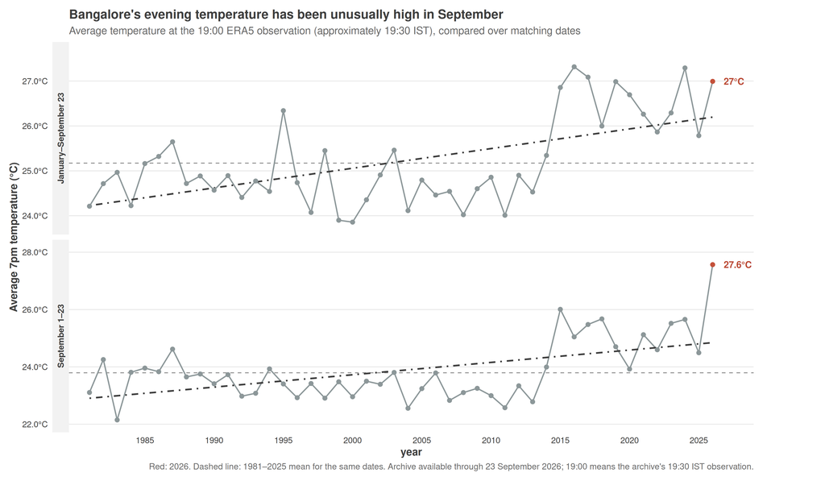

```r
ytd_plot <- ytd %>% transmute(year, mean_7pm, panel = paste0("January–September ", cutoff_month_day))
sep_plot <- september %>% transmute(year, mean_7pm, panel = paste0("September 1–", cutoff_month_day))
plot_data <- bind_rows(ytd_plot, sep_plot) %>%
  mutate(panel = factor(panel, levels = c(paste0("January–September ", cutoff_month_day), paste0("September 1–", cutoff_month_day))),
         current = year == 2026)

reference_lines <- bind_rows(
  tibble(panel = factor(paste0("January–September ", cutoff_month_day), levels = levels(plot_data$panel)),
         reference = mean(historical_ytd$mean_7pm)),
  tibble(panel = factor(paste0("September 1–", cutoff_month_day), levels = levels(plot_data$panel)),
         reference = mean(historical_september$mean_7pm))
)

labels <- plot_data %>% filter(current) %>%
  mutate(label = paste0(round(mean_7pm, 1), "°C"))

chart_path <- file.path(chart_dir, "september-evening-temperature.png")
p <- ggplot(plot_data, aes(year, mean_7pm)) +
  geom_hline(data = reference_lines, aes(yintercept = reference),
             color = "grey55", linewidth = 0.45, linetype = "dashed") +
  geom_line(color = "#8C9799", linewidth = 0.65) +
  geom_smooth(aes(group = 1), method = "lm", formula = y ~ x,
              se = FALSE, color = "#3C3C3C", linewidth = 0.8,
              linetype = "dotdash") +
  geom_point(aes(color = current), size = 1.8) +
  geom_text(data = labels, aes(label = label),
            nudge_x = 0.8, hjust = 0, color = "#B94732", fontface = "bold", size = 3.4) +
  scale_color_manual(values = c(`FALSE` = "#8C9799", `TRUE` = "#C4513A")) +
  facet_grid(panel ~ ., scales = "free_y", switch = "y") +
  scale_x_continuous(breaks = seq(1985, 2025, 5),
                     limits = c(1980, 2028), expand = expansion(mult = c(0.01, 0.02))) +
  scale_y_continuous(labels = label_number(accuracy = 0.1, suffix = "°C"),
                     expand = expansion(mult = c(0.08, 0.16))) +
  labs(title = "Bangalore's evening temperature has been unusually high in September",
       subtitle = "Average temperature at the 19:00 ERA5 observation (approximately 19:30 IST), compared over matching dates",
       y = "Average 7pm temperature (°C)",
       caption = paste0("Red: 2026. Dashed line: 1981–2025 mean for the same dates. Archive available through ", format(last_current_date, "%d %B %Y"), "; 19:00 means the archive's 19:30 IST observation.")) +
  theme_weather() +
  theme(axis.text.x = element_text(angle = 0),
        axis.title = element_text(color = "#3C3C3C", face = "bold"),
        plot.margin = margin(10, 75, 10, 10))
p
```

```r
ggsave(chart_path, p, width = 12, height = 7, dpi = 180, bg = "white")
```

## Checks and interpretation

- The comparison uses the same January 1–September 23 calendar window in every year, avoiding the mistake of comparing an incomplete 2026 year with complete years.
- September uses September 1–23 in every year, not a full September for the historical baseline.
- The 2026 ERA5 data currently ends on September 23, even though the calendar month has continued. This result should be rerun when later archive rows become available.
- The archive timestamp labelled 19:00 in this analysis is the 19:30 IST observation. It is a consistent evening measure, but not a literal instantaneous 19:00 reading.
- This establishes an unusually warm evening pattern, not why it happened. Cloud cover, humidity, wind and rainfall are possible contributors, but they need a separate analysis.

## Verdict

Insightful: yes

The feeling is supported by the archive, especially in September. Through September 23, 2026’s average evening temperature was 27°C, the 4th-highest matching-period value in 46 years. September 1–23 was the clearest result: 27.6°C against a historical 23.8°C, making it the warmest comparable opening of September in the archive. This is a strong enough descriptive result to keep, while the incomplete current month and ERA5 timestamp caveats should remain visible.

Charts:

- `docs/assets/analysis/september-evening-temperature.png`

Blog post:

- not published; await explicit `/weather_publish september-evening-temperature`